# Tutorial: Subgroup Cox Forest Plots Using the lung Dataset

Example analysis

# Overview

This tutorial demonstrates how to use `cox_subgroup_forest()` with the built-in `lung` dataset from the **survival** package.

The function was written to create publication-style subgroup forest plots from treatment-effect Cox proportional-hazards models. It fits

```r
Surv(time, event) ~ treatment
```

within each subgroup and reports hazard ratios (HRs), 95% confidence intervals, p-values, sample sizes, events, and median survival by arm.

> **Important:** `lung` does not contain a randomised treatment variable. For a software demonstration, this tutorial uses `sex` as the two-level comparison variable. The resulting HRs are observational sex comparisons, not treatment effects.

# 1. Packages

```r
library(survival)
library(dplyr)
library(tidyr)

source("forestplot_favouring_function.R")
```

The main function also uses `broom`, `purrr`, `ggplot2`, `forestploter`, `tibble`, `stringr`, and `grid`.

# 2. Load the lung data

```r
data("lung", package = "survival")
dim(lung)
```

```
## [1] 228  10
```

```r
head(lung)
```

```
##   inst time status age sex ph.ecog ph.karno pat.karno meal.cal wt.loss
## 1    3  306      2  74   1       1       90       100     1175      NA
## 2    3  455      2  68   1       0       90        90     1225      15
## 3    3 1010      1  56   1       0       90        90       NA      15
## 4    5  210      2  57   1       1       90        60     1150      11
## 5    1  883      2  60   1       0      100        90       NA       0
## 6   12 1022      1  74   1       1       50        80      513       0
```

The key variables used here are:

- `time`: observed survival time;
- `status`: censoring/event indicator;
- `sex`: coded as 1/2;
- `ph.ecog`: ECOG performance status; and
- `age`: patient age.

# 3. Prepare the analysis dataset

The requested transformation is applied below.

```r
df <- lung %>%
  mutate(
    sex        = factor(
      sex,
      levels = c(1, 2),
      labels = c("Male", "Female")
    ),
    ecog       = factor(
      ph.ecog,
      levels = c(0, 1, 2, 3),
      labels = c("ECOG 0", "ECOG 1", "ECOG 2", "ECOG 3")
    ),
    age_grp    = factor(
      ifelse(age < 63, "Age < 63", "Age >= 63")
    ),
    status_bin = as.numeric(status == 2)
  ) %>%
  drop_na(time, status_bin, sex, ecog, age_grp, age)

df %>%
  count(sex)
```

```
##      sex   n
## 1   Male 137
## 2 Female  90
```

```r
df %>%
  count(ecog)
```

```
##     ecog   n
## 1 ECOG 0  63
## 2 ECOG 1 113
## 3 ECOG 2  50
## 4 ECOG 3   1
```

```r
df %>%
  count(age_grp)
```

```
##     age_grp   n
## 1  Age < 63 105
## 2 Age >= 63 122
```

`status_bin` is coded as 1 for the event and 0 for censoring.

# 4. Define the comparison arms

The function requires exactly two treatment levels. Because `lung` has no treatment variable, the demonstration uses `sex`:

```r
table(df$sex)
```

```
##
##   Male Female
##    137     90
```

```r
arm_order <- c("Male", "Female")
arm_labels <- c("Male", "Female")
```

This means the fitted model coefficient represents:

```
Male vs Female
```

and HR < 1 corresponds to lower hazard in males relative to females.

Again, this is only a demonstration of the function.

# 5. Run the subgroup forest analysis

We will examine two subgroup variables:

- ECOG performance status;
- age group.

```r
result <- cox_subgroup_forest(
  data = df,
  covariates = c("ecog", "age_grp"),
  labels = c(
    "ECOG performance status",
    "Age group"
  ),
  treatment = "sex",
  time = "time",
  event = "status_bin",
  endpoint_labels = "Overall survival",
  arm_order = arm_order,
  treatment_labels = arm_labels,
  palette = "grey30",
  time_unit = "months",
  length_plot = 60,
  ci_pch = 15,
  ci_lty = 1,
  ci_lwd = 3,
  ci_Theight = 0.4,
  sizes = 1
)
```

# 6. Examine the results table

```r
result$results_table
```

```
## # A tibble: 8 × 14
##   covariate covariate_label        subgroup indent endpoint endpoint_label     n
##   <chr>     <chr>                  <chr>    <lgl>  <chr>    <chr>          <int>
## 1 ecog      ECOG performance stat… All pat… FALSE  time     Overall survi…   227
## 2 ecog      ECOG performance stat… ECOG 0   TRUE   time     Overall survi…    63
## 3 ecog      ECOG performance stat… ECOG 1   TRUE   time     Overall survi…   113
## 4 ecog      ECOG performance stat… ECOG 2   TRUE   time     Overall survi…    50
## 5 ecog      ECOG performance stat… ECOG 3   TRUE   time     Overall survi…     1
## 6 age_grp   Age group              All pat… FALSE  time     Overall survi…   227
## 7 age_grp   Age group              Age < 63 TRUE   time     Overall survi…   105
## 8 age_grp   Age group              Age >= … TRUE   time     Overall survi…   122
## # ℹ 7 more variables: n_event <dbl>, median_a <dbl>, median_b <dbl>, hr <dbl>,
## #   conf_low <dbl>, conf_high <dbl>, p_value <dbl>
```

The table contains:

- `subgroup`: subgroup definition;
- `n`: number of observations used;
- `n_event`: number of events;
- `median_a`: median survival for Arm A;
- `median_b`: median survival for Arm B;
- `hr`: hazard ratio;
- `conf_low` and `conf_high`: 95% CI;
- `p_value`: Wald p-value from the Cox model.

For this example, Arm A is Male and Arm B is Female.

# 7. Median survival table

A compact median-survival table is available:

```r
result$median_survival_table
```

```
## # A tibble: 8 × 7
##   covariate_label         subgroup     endpoint_label      n n_event median_Male
##   <chr>                   <chr>        <chr>           <int>   <dbl>       <dbl>
## 1 ECOG performance status All patients Overall surviv…   227     164         270
## 2 ECOG performance status ECOG 0       Overall surviv…    63      37         353
## 3 ECOG performance status ECOG 1       Overall surviv…   113      82         239
## 4 ECOG performance status ECOG 2       Overall surviv…    50      44         166
## 5 ECOG performance status ECOG 3       Overall surviv…     1       1         118
## 6 Age group               All patients Overall surviv…   227     164         270
## 7 Age group               Age < 63     Overall surviv…   105      72         286
## 8 Age group               Age >= 63    Overall surviv…   122      92         270
## # ℹ 1 more variable: median_Female <dbl>
```

This can be useful when creating supplementary tables or checking the values displayed in the forest plot.

# 8. Plot ECOG subgroup results

The function returns a forest plot for each covariate.

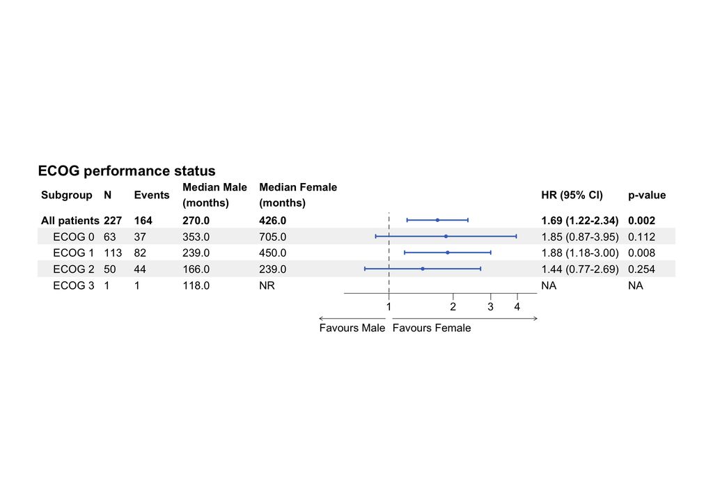

```r
result$plots[["ECOG performance status"]]
```

The plot contains an **All patients** estimate followed by the individual ECOG subgroups.

The x-axis is logarithmic and the vertical reference line is HR = 1.

# 9. Plot age-group results

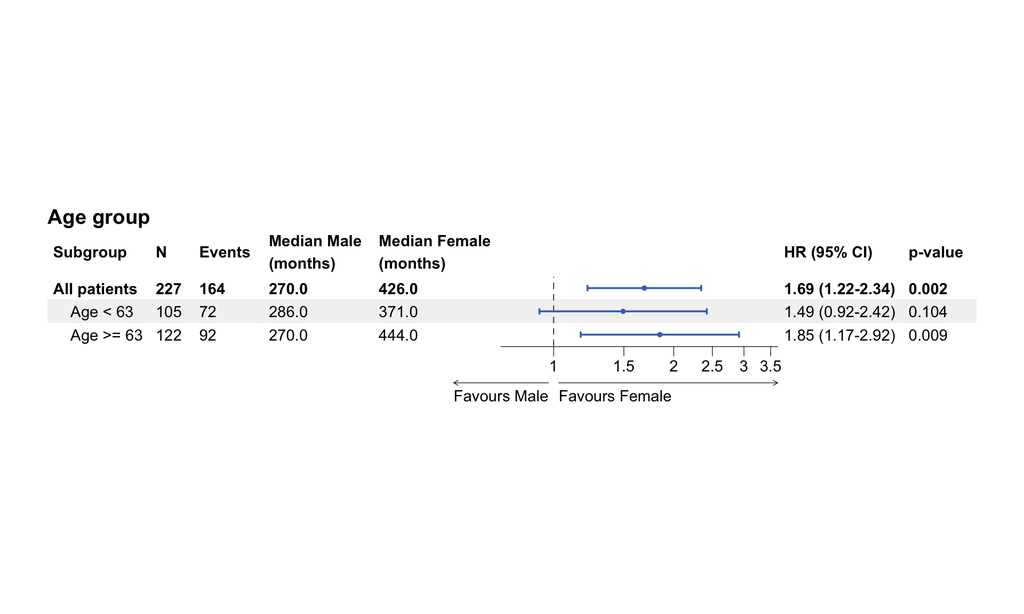

```r
result$plots[["Age group"]]
```

The same modelling and display approach is used for the age subgroups.

# 10. Combined forest plot

A combined forest plot is also returned:

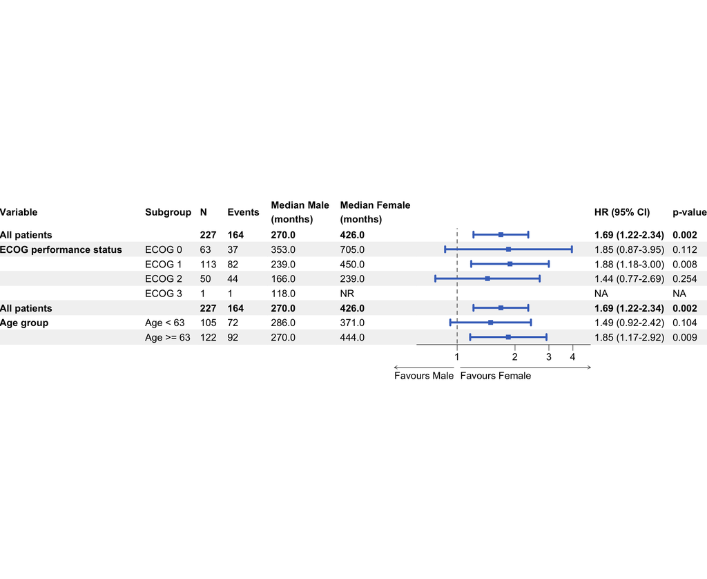

```r
result$combined_plots
```

This provides a compact overview of the subgroup estimates from both covariates.

# 11. Access the fitted Cox models

The fitted models are stored in `result$models`.

```r
names(result$models)
```

```
## [1] "ECOG performance status" "Age group"
```

```r
names(result$models[["ECOG performance status"]])
```

```
## [1] "ECOG performance status | All patients | Overall survival"
## [2] "ECOG performance status | ECOG 0 | Overall survival"
## [3] "ECOG performance status | ECOG 1 | Overall survival"
## [4] "ECOG performance status | ECOG 2 | Overall survival"
```

A particular model can be extracted and inspected with standard `survival` methods:

```r
fit <- result$models[["ECOG performance status"]][[
  "ECOG performance status | ECOG 2 | Overall survival"
]]

summary(fit)
```

```
## Call:
## survival::coxph(formula = fmla, data = d)
##
##   n= 50, number of events= 44
##
##           coef exp(coef) se(coef)     z Pr(>|z|)
## sexMale 0.3638    1.4387   0.3189 1.141    0.254
##
##         exp(coef) exp(-coef) lower .95 upper .95
## sexMale     1.439      0.695    0.7701     2.688
##
## Concordance= 0.581  (se = 0.04 )
## Likelihood ratio test= 1.33  on 1 df,   p=0.2
## Wald test            = 1.3  on 1 df,   p=0.3
## Score (logrank) test = 1.32  on 1 df,   p=0.3
```

The exact subgroup names available depend on the data after missing-value filtering.

# 12. Continuous covariates

The function can also treat a numeric covariate as continuous.

For example, use age directly:

```r
result_age <- cox_subgroup_forest(
  data = df,
  covariates = c("age"),
  labels = c("Age"),
  treatment = "sex",
  time = "time",
  event = "status_bin",
  endpoint_labels = "Overall survival",
  continuous_vars = "age",
  arm_order = arm_order,
  treatment_labels = arm_labels,
  palette = "grey30",
  time_unit = "months"
)
```

For the forest plot, age is divided at its median into two groups. The function also returns a separate per-unit effect:

```r
result_age$continuous_effects
```

```
## # A tibble: 1 × 10
##   covariate covariate_label endpoint endpoint_label      hr conf_low conf_high
##   <chr>     <chr>           <chr>    <chr>            <dbl>    <dbl>     <dbl>
## 1 age       Age             time     Overall survival  1.02    0.998      1.04
## # ℹ 3 more variables: p_value <dbl>, n <int>, interpretation <chr>
```

This is an important distinction:

- the forest-plot rows estimate the **Male vs Female** hazard ratio within age-defined groups;
- `continuous_effects` estimates the hazard ratio associated with a **one-unit increase in age**, adjusted for treatment through stratification.

These are different quantities.

# 13. Interpreting an HR

If a row has an HR such as:

```
0.70 (0.50-0.98)
```

the estimate is a 30% lower hazard for Arm A relative to Arm B, with a 95% CI from 0.50 to 0.98.

The direction follows the function’s fixed coding:

```
HR = Arm A / Arm B
```

In this tutorial:

```
Arm A = Male
Arm B = Female
```

Therefore, the interpretation is a comparison of males with females.

# 14. Changing the length of the plot and the ticks and x limits

Automatically, there will be 5 ticks and labels and the length is 40 spaces.

```r
result <- cox_subgroup_forest(
  data = df,
  covariates = c("ecog", "age_grp"),
  labels = c(
    "ECOG performance status",
    "Age group"
  ),
  treatment = "sex",
  time = "time",
  event = "status_bin",
  endpoint_labels = "Overall survival",
  arm_order = arm_order,
  treatment_labels = arm_labels,
  palette = "grey30",
  time_unit = "months",
  length_plot = 50,
  xlim = c(0.5, 6),
  ticks_at = c(0.5, 1, 2, 4),
  ci_pch = 20,
  ci_lty = 1,
  ci_lwd = 3,
  ci_Theight = 0.4,
  sizes = 1
)
```

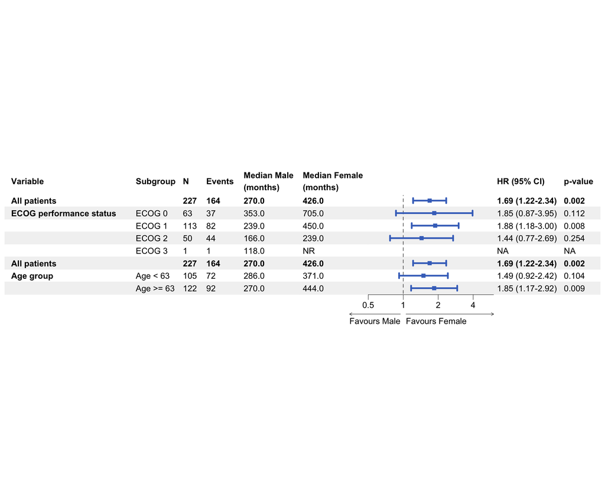

```r
result$combined_plots
```

# 15. Exporting results

The results table is an ordinary data frame, so it can be exported with standard R tools:

```r
write.csv(
  result$results_table,
  "lung_subgroup_cox_results.csv",
  row.names = FALSE
)
```

The forest plot object can be drawn on a graphics device such as PDF or PNG using standard R graphics workflows. The supplied function itself returns `forestploter` objects rather than writing files automatically.

# 16. Recommended use with real trial data

For a real randomised trial, replace the demonstration `sex` variable with the actual two-level treatment-arm variable.

For example:

```r
result <- cox_subgroup_forest(
  data = trial_data,
  covariates = c("sex", "age_grp", "ecog"),
  labels = c("Sex", "Age group", "ECOG"),
  treatment = "treatment",
  time = "os_time",
  event = "os_event",
  endpoint_labels = "Overall survival",
  arm_order = c("Treatment A", "Treatment B"),
  treatment_labels = c("Treatment A", "Treatment B"),
  palette = "grey30"
)
```

For formal subgroup inference, do not rely on within-subgroup p-values alone. A treatment-by-subgroup interaction analysis is generally needed to test whether treatment effects differ between subgroups.

# 17. Summary

The key workflow is:

1. load the survival data;
2. create appropriately coded variables;
3. identify a two-level treatment variable;
4. specify subgroup covariates;
5. pair survival time and event variables;
6. run `cox_subgroup_forest()`;
7. inspect `results_table`;
8. inspect the individual or combined forest plots; and
9. interpret the HR according to the specified `arm_order`.

The `lung` example is intended to make the code reproducible and easy to learn. It should not be interpreted as a causal treatment analysis.